# Comparing Two Means

Erin M. Buchanan

Last Updated: 2021-02-06

# Experiments

- **Simple experiments:**
  - One IV that’s binary with two options
  - One DV that’s interval/ratio/continuous
- **For example:** manipulation of the independent variable involves having an experimental condition and a control.
  - This situation can be analyzed with a t-test.
  - We can also use t-tests to analyze any binary independent variable.
  - The t-test is a simple regression model with one categorical predictor.

# Experiments

- Don’t make a continuous variable categorical just so you can do a t-test.
- People used to split variables into high versus low or simply split down the middle.
  - You separate the people who are close together and lump them with people who are not really like them.
  - Effect sizes get smaller.
  - You will also decrease power and see Type II errors.

# Experiments

- **Reminder:**
  - When you manipulate the levels of the IV, you are working with experimental research.
  - If you just are examining two naturally occurring categories, then quasi-experimental/correlational.

# Experiments

- Between subjects / Independent designs
  - Expose different groups to different experimental manipulations.
- Repeated measures / within subjects / dependent designs
  - Take a single group of people and expose them to different experimental manipulations at different points in time.

# The t-test

- **Independent t-test:**
  - Compares two means based on independent data
  - Used when different participants were assigned to each condition of the study
- **Dependent t-test:**
  - Compares two means based on related data.
  - Used when the same participants took part in both conditions of the study

# Independent: Example

- Are invisible people mischievous?
- Manipulation
  - Placed participants in an enclosed community riddled with hidden cameras.
  - 12 participants were given an invisibility cloak.
  - 12 participants were not given an invisibility cloak.
- Outcome measured how many mischievous acts participants performed in a week.

```r
library(rio)
longdata <- import("data/invisible.csv")
str(longdata)
```

```
## 'data.frame':    24 obs. of  2 variables:
##  $ Cloak   : chr  "No Cloak" "No Cloak" "No Cloak" "No Cloak" ...
##  $ Mischief: int  3 1 5 4 6 4 6 2 0 5 ...
```

# Independent: Understanding the NHST

- H0: The no cloak and cloak groups would have the same mean.
- H1: The no cloak and cloak groups would have different means.

```r
M <- tapply(longdata$Mischief, longdata$Cloak, mean)
STDEV <- tapply(longdata$Mischief, longdata$Cloak, sd)
N <- tapply(longdata$Mischief, longdata$Cloak, length)

M;STDEV;N
```

```
##    Cloak No Cloak
##     5.00     3.75
```

```
##    Cloak No Cloak
## 1.651446 1.912875
```

```
##    Cloak No Cloak
##       12       12
```

# Independent: Understanding the NHST

- Our means appear slightly different. What might have caused those differences?
  - Variance created by our manipulation: The cloak **(systematic variance)**
  - Variance created by unknown factors **(unsystematic variance)**

[figure not shown]

# Independent: Understanding the NHST

- If the samples come from the same population, then we expect their means to be roughly equal.
- Although it is possible for their means to differ by chance alone, here, we would expect large differences between sample means to occur very infrequently.
- We compare the difference between the sample means that we collected to the difference between the sample means that we would expect to obtain if there were no effect **(i.e. if the null hypothesis were true)**.

# Independent: Understanding the NHST

- We use the standard error as a gauge of the variability between sample means. - If the difference between the samples we have collected is larger than what we would expect based on the standard error then we can assume one of two interpretations:
  - There is no effect and sample means in our population fluctuate a lot and we have, by chance, collected two samples that are atypical of the population from which they came *(Type 1 error)*.
  - The two samples come from different populations but are typical of their respective parent population. In this scenario, the difference between samples represents a genuine difference between the samples *(and so the null hypothesis is incorrect)*.

# Independent: Understanding the NHST

- As the observed difference between the sample means gets larger, the more confident we become that the second explanation is correct (i.e., that the null hypothesis should be rejected).
- If the null hypothesis is incorrect, then we gain confidence that the two sample means differ because of the different experimental manipulation imposed on each sample.

# Independent: Formulas

- Embedded in the formula are all the things we’ve discussed for model fit: the means, degrees of freedom, standard deviation, standard error

$$t = \frac {\bar{X}_1 - \bar{X}_2}{\sqrt {\frac {s^2_p}{n_1} + \frac {s^2_p}{n_2}}}$$

$$s^2_p = \frac {(n_1-1)s^2_1 + (n_2-1)s^2_2} {n_1+n_2-2}$$

# Independent: Data Screening

- Accuracy
- Missing - just exclude them!
- Outliers: We only have one continuous measure to screen, therefore, outliers can be screened by *Z*-scores.
- Assumptions:
  - Linearity
  - Normality
  - Homogeneity: Equal variances between groups

# Independent: Analysis

- No differences between groups was found: $t(22) = 1.71, p = .101$

```r
t.test(Mischief ~ Cloak,
       data = longdata,
       var.equal = TRUE, #assume equal variances
       paired = FALSE) #independent
```

```
##
##  Two Sample t-test
##
## data:  Mischief by Cloak
## t = 1.7135, df = 22, p-value = 0.1007
## alternative hypothesis: true difference in means is not equal to 0
## 95 percent confidence interval:
##  -0.2629284  2.7629284
## sample estimates:
##    mean in group Cloak mean in group No Cloak
##                   5.00                   3.75
```

# Independent: No Homogeneity

- The most common problem is homogeneity … where the group variance is not equal between groups.
- You can easily adjust for variances using the Welch *(or Satterthwaite)* approximation to the degrees of freedom
- Set `var.equal = FALSE` to use this adjustment.
- For other issues you can try the Wilcoxon Signed-Rank Test.

```r
t.test(Mischief ~ Cloak,
       data = longdata,
       var.equal = FALSE, #assume equal variances
       paired = FALSE) #independent
```

```
##
##  Welch Two Sample t-test
##
## data:  Mischief by Cloak
## t = 1.7135, df = 21.541, p-value = 0.101
## alternative hypothesis: true difference in means is not equal to 0
## 95 percent confidence interval:
##  -0.264798  2.764798
## sample estimates:
##    mean in group Cloak mean in group No Cloak
##                   5.00                   3.75
```

# Independent: Effect Size

- Effect size options:
  - Cohen’s d for independent t = $d_s$
  - Hedges’ g
  - Glass’ $\Delta$
  - r

# Independent: Effect Size

- While our statistical test indicated no differences, the effect size indicates a medium difference between means.
- This difference in interpretation is likely due to low power with a small sample size.

```r
library(MOTE)
effect <- d.ind.t(m1 = M[1], m2 = M[2],
                  sd1 = STDEV[1], sd2 = STDEV[2],
                  n1 = N[1], n2 = N[2], a = .05)
effect$d
```

```
##     Cloak
## 0.6995169
```

# Independent: Power

- So, how many people would I need to power this test?

```r
library(pwr)
pwr.t.test(n = NULL, #leave NULL
           d = effect$d, #effect size
           sig.level = .05, #alpha
           power = .80, #power
           type = "two.sample", #independent
           alternative = "two.sided") #two tailed test
```

```
##
##      Two-sample t test power calculation
##
##               n = 33.0688
##               d = 0.6995169
##       sig.level = 0.05
##           power = 0.8
##     alternative = two.sided
##
## NOTE: n is number in *each* group
```

# Dependent: Example

- Are invisible people mischievous?
- Manipulation
  - Placed participants in an enclosed community riddled with hidden cameras.
  - For first week participants normal behavior was observed.
  - For the second week, participants were given an invisibility cloak.
- Outcome: We measured how many mischievous acts participants performed in week 1 and week 2.
- **Note:** Same data, but instead the study is dependent. Let’s see what happens to our t-test. You would not change the analysis this way, but this example shows how the type of experiment and statistical test can affect power and results.

# Dependent: Understanding the NHST

- The logic of this test is roughly the same, but you have to consider the matched nature of dependent results.
- We are going to use the standard error of the differences rather than standard error.
- The standard error of the differences is calculated by subtracting the two sets of scores and calculating standard deviation on that difference score.

$$t = \frac {\bar{D} - \mu_D}{S_D/\sqrt N}$$

# Dependent: Data Screening

- The data screening can be treated in the same fashion.
- However, homogeneity between groups is not examined, because you do not have separate groups!
- The variance is calculated on **one difference** score, so there is not homogeneity concern.
- When other assumptions are not met, you can use a Mann-Whitney Test or the Wilcoxon rank-sum test.

# Dependent: Analysis

- The cloak and no cloak conditions were different: $t(11) = 3.80, p = .003$.
- Why is this result different than independent t?

```r
t.test(Mischief ~ Cloak,
       data = longdata,
       var.equal = TRUE, #ignored in dependent t
       paired = TRUE) #dependent t
```

```
##
##  Paired t-test
##
## data:  Mischief by Cloak
## t = 3.8044, df = 11, p-value = 0.002921
## alternative hypothesis: true difference in means is not equal to 0
## 95 percent confidence interval:
##  0.5268347 1.9731653
## sample estimates:
## mean of the differences
##                    1.25
```

# Dependent: Effect Size

- Cohen’s d: Based on averages
  - $d_{av}$ looks at both SDs without controlling for r
  - $d_{rm}$ looks at both SDs and controls for r
- Cohen’s d: Based on differences $d_z$
- Which one should I use?

# Dependent: Effect Size

```r
effect2 <- d.dep.t.avg(m1 = M[1], m2 = M[2],
                       sd1 = STDEV[1], sd2 = STDEV[2],
                       n = N[1], a = .05)
effect2$d
```

```
##     Cloak
## 0.7013959
```

```r
#remember independent t
effect$d
```

```
##     Cloak
## 0.6995169
```

# Dependent: Effect Size

- If we were to use $d_z$, we would overestimate the effect size.
- You do not normally have to calculate both, just showing how these are different.
- Create difference scores, calculate the difference score measures.

```r
diff <- longdata$Mischief[longdata$Cloak == "Cloak"] - longdata$Mischief[longdata$Cloak == "No Cloak"]

effect2.1 = d.dep.t.diff(mdiff = mean(diff, na.rm = T),
                         sddiff = sd(diff, na.rm = T),
                         n = length(diff), a = .05)
effect2.1$d
```

```
## [1] 1.098244
```

# Dependent: Power

```r
pwr.t.test(n = NULL,
           d = effect2$d,
           sig.level = .05,
           power = .80,
           type = "paired",
           alternative = "two.sided")
```

```
##
##      Paired t test power calculation
##
##               n = 17.96948
##               d = 0.7013959
##       sig.level = 0.05
##           power = 0.8
##     alternative = two.sided
##
## NOTE: n is number of *pairs*
```

# t-test: Visualization

- Bar charts in ggplot2 with only one x variable (the different levels of your IV) and one y variable.

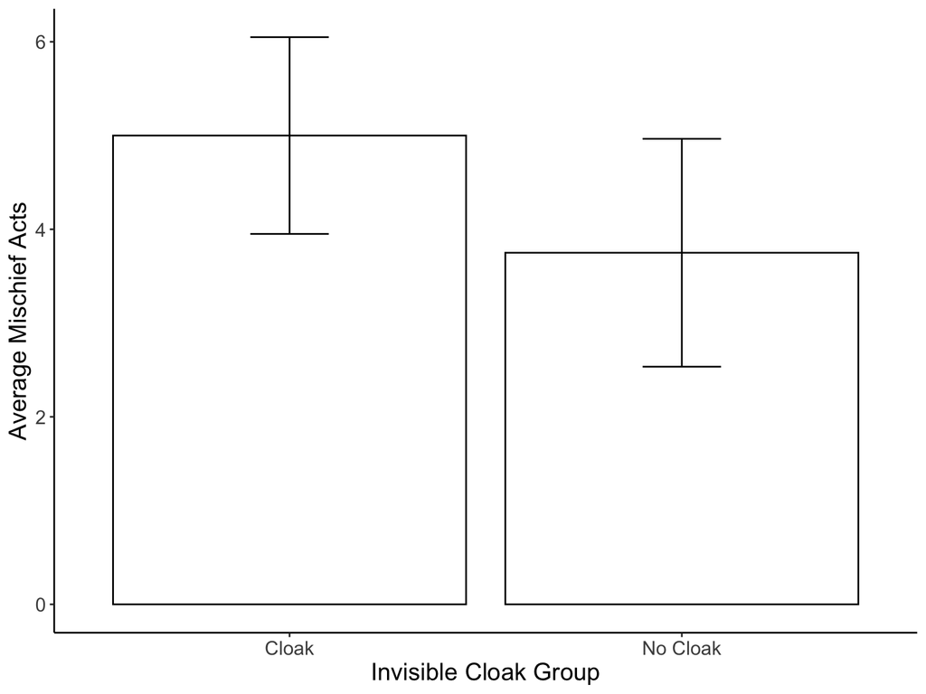

```r
library(ggplot2)

cleanup <- theme(panel.grid.major = element_blank(),
                panel.grid.minor = element_blank(),
                panel.background = element_blank(),
                axis.line.x = element_line(color = "black"),
                axis.line.y = element_line(color = "black"),
                legend.key = element_rect(fill = "white"),
                text = element_text(size = 15))

bargraph <- ggplot(longdata, aes(Cloak, Mischief))

bargraph +
  cleanup +
  stat_summary(fun.y = mean,
               geom = "bar",
               fill = "White",
               color = "Black") +
  stat_summary(fun.data = mean_cl_normal,
               geom = "errorbar",
               width = .2,
               position = "dodge") +
  xlab("Invisible Cloak Group") +
  ylab("Average Mischief Acts")
```

# Summary

- In this lecture, you’ve learned:
  - All things t-tests
  - The logic of t-tests
  - Independent and dependent t-tests
  - Effect sizes for t-tests
  - Power for t-tests